# MELD Project: The <em>M</em>etabolic consequences of adverse <em>E</em>arly <em>L</em>ife conditions and subsequent risk for adult type 2 <em>D</em>iabetes

## DDA Start-up Presentation

### Luke W. Johnston

# Outline:

- Project description

- Plans during funding

- Future perspectives

- Challenges

# MELD Project Description

## Brief introduction

- Early life influences risk for diabetes

- How metabolic processes mediate link? 🤷🤷

- Difficult to study due to long timespans

## Research questions:

- *Aim*: To quantify and understand impact of early life conditions on adult
metabolic capacity and risk for T2D.

### Objectives

1. Investigate how specific early life conditions affect risk of T2D nationally
1. Extend and generalise NetCoupler algorithm
([github.com/NetCoupler](https://github.com/NetCoupler/NetCoupler))
    - Estimates direct and mediating pathways in high dimensional metabolic data
1. Identify mediating pathways of metabolic capacity between early
life adversity and T2D using NetCoupler

## Methods: Population

[figure not shown]

## Methods: Variables

[figure not shown]

## Methods: Analysis process

[figure not shown]

## Analyzing data that looks like:

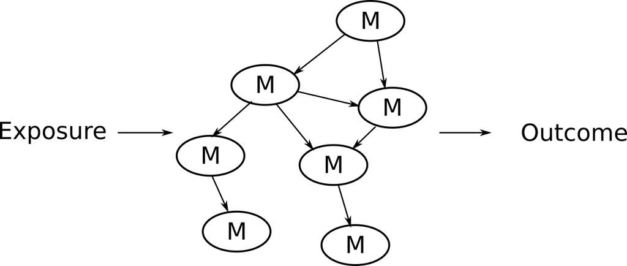

## NetCoupler: A causal structure learning algorithm that...

- Finds most likely network structure

- Allows inclusion of exposure and outcome

- Identifies causal links between and within network

[figure not shown]

NetCoupler algorithm was developed by Clemens Wittenbecher.

## NetCoupler procedure

[figure not shown]

## Infer (potentially) causal pathways with graphical model

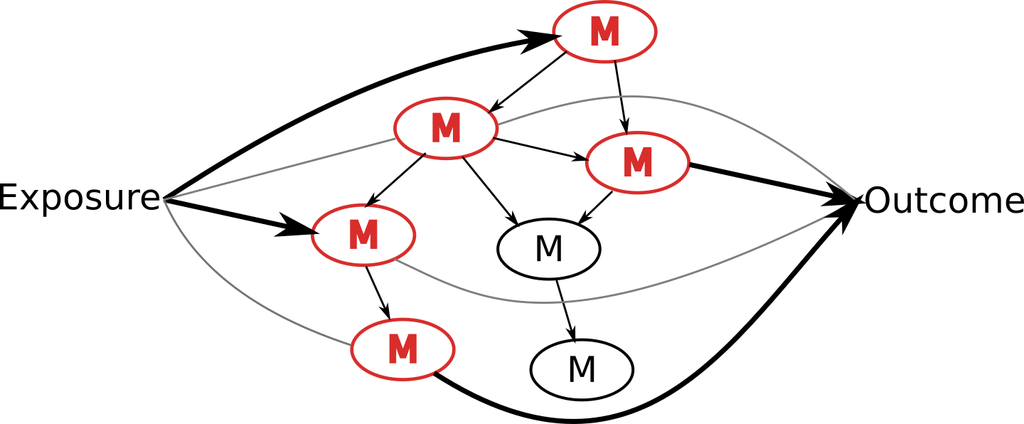

## General timeline

[figure not shown]